[figure not shown]

[figure not shown]

[figure not shown]

# Title

(G)RDPG with Covariates

Cong Mu

04/14/2019

# Change of Latent Position

- Simulations to test the performance of our procedure for different latent position
  - Number of Nodes: `n = [2000, 5000, 10000, 20000]`
  - Number of Blocks: `K = 2`
  - Dimension of Latent Position: `d = 1`
  - Size of Each Block: `pi_1 = pi_2 = 0.5`
  - Proportion of One Binary Covariate: `pi_z_1 = pi_z_2 = 0.5`
  - Latent Position:
    - Block 1: `p = -1.5`
    - Block 2: `q = [-1.25, -1, -0.75, -0.5, -0.25, 0.25, 0.5, 0.75, 1, 1.25, 1.5]`
  - Effect of Covariate: `beta = [-3, 3, -1, 1]`

# Change of Size of Each Block

- Simulations to test the performance of our procedure for different size of each block
  - Number of Nodes: `n = [2000, 5000, 10000, 20000]`
  - Number of Blocks: `K = 2`
  - Dimension of Latent Position: `d = 1`
  - Size of Each Block: `(pi_1,pi_2) = [(0.05,0.95), (0.1,0.9), (0.15,0.85), (0.2,0.8), (0.25,0.75), (0.3,0.7), (0.35,0.65), (0.4,0.6), (0.45,0.55), (0.5,0.5)]`
  - Proportion of One Binary Covariate: `pi_z_1 = pi_z_2 = 0.5`
  - Latent Position: `(p,q) = (-1.5,1.5)`
  - Effect of Covariate: `beta = 1`

# Change of Proportion of One Binary Covariate

# Change of Size of Each Block and Proportion of One Binary Covariate

- Simulations to test the performance of our procedure for different size of each block and proportion of one binary covariate
  - Number of Nodes: `n = [2000, 5000, 10000, 20000]`
  - Number of Blocks: `K = 2`
  - Dimension of Latent Position: `d = 1`
  - Size of Each Block: `(pi_1,pi_2) = [(0.05,0.95), (0.1,0.9), (0.15,0.85), (0.2,0.8), (0.25,0.75), (0.3,0.7), (0.35,0.65), (0.4,0.6), (0.45,0.55), (0.5,0.5)]`
  - Proportion of One Binary Covariate: `(pi_z_1,pi_z_2) = [(0.05,0.95), (0.1,0.9), (0.15,0.85), (0.2,0.8), (0.25,0.75), (0.3,0.7), (0.35,0.65), (0.4,0.6), (0.45,0.55), (0.5,0.5)]`
  - Latent Position: `(p,q) = (-1.5,1.5)`
  - Effect of Covariate: `beta = 1`

# Change of Latent Position

### **pi_1 = pi_2 = 0.5, pi_z_1 = pi_z_2 = 0.5**

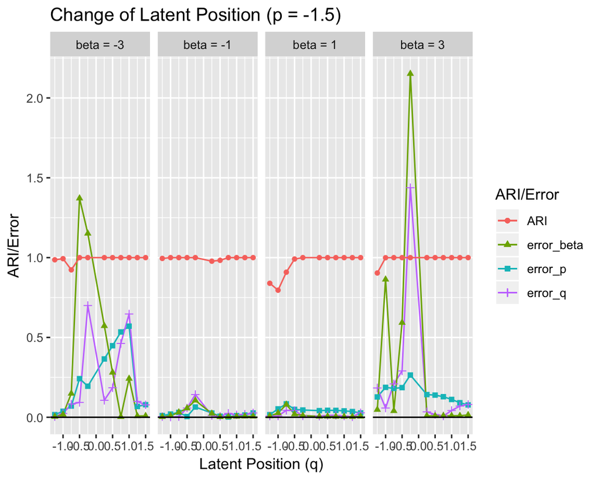

### **pi_1 = pi_2 = 0.5, pi_z_1 = pi_z_2 = 0.5**

| n | p | q | phat | qhat | beta | betahat | ARI |
| --- | --- | --- | --- | --- | --- | --- | --- |
| 2000 | -1.5 | -1.25 | -1.514913 | -1.2469150 | -3 | -2.9992735 | 0.9946694 |
| 2000 | -1.5 | -1.25 | -1.514710 | -1.2445959 | -3 | -2.9989396 | 1.0000000 |
| 2000 | -1.5 | -1.25 | -1.513143 | -1.2417003 | -3 | -2.9931529 | 0.9973347 |
| 2000 | -1.5 | -1.25 | -1.517784 | -1.2443190 | -3 | -2.9986582 | 0.9920147 |
| 2000 | -1.5 | -1.25 | -1.515839 | -1.2459447 | -3 | -3.0018753 | 0.9946720 |
| 2000 | -1.5 | -1.25 | -1.517341 | -1.2475322 | -3 | -3.0057088 | 0.9960007 |
| 2000 | -1.5 | -1.25 | -1.517925 | -1.2463073 | -3 | -3.0009162 | 0.9867376 |
| 2000 | -1.5 | -1.25 | -1.521586 | -1.2484752 | -3 | -3.0170535 | 0.9123233 |
| 2000 | -1.5 | -1.25 | -1.515370 | -1.2447532 | -3 | -2.9962843 | 0.9960060 |
| 2000 | -1.5 | -1.25 | -1.516955 | -1.2465636 | -3 | -3.0015929 | 0.9946693 |
| 2000 | -1.5 | -1.00 | -1.538045 | -0.9753602 | -3 | -3.0149848 | 1.0000000 |
| 2000 | -1.5 | -1.00 | -1.537625 | -0.9730380 | -3 | -3.0178622 | 1.0000000 |
| 2000 | -1.5 | -1.00 | -1.544198 | -0.9716868 | -3 | -3.0225063 | 0.9339793 |
| 2000 | -1.5 | -1.00 | -1.538054 | -0.9749883 | -3 | -3.0119007 | 1.0000000 |
| 2000 | -1.5 | -1.00 | -1.534243 | -0.9771445 | -3 | -3.0157704 | 1.0000000 |
| 2000 | -1.5 | -1.00 | -1.530145 | -0.9815612 | -3 | -3.0152974 | 1.0000000 |
| 2000 | -1.5 | -1.00 | -1.540004 | -0.9784410 | -3 | -3.0212786 | 1.0000000 |
| 2000 | -1.5 | -1.00 | -1.537985 | -0.9790262 | -3 | -3.0221948 | 1.0000000 |
| 2000 | -1.5 | -1.00 | -1.535927 | -0.9762080 | -3 | -3.0156429 | 1.0000000 |
| 2000 | -1.5 | -1.00 | -1.540152 | -0.9742564 | -3 | -3.0187718 | 1.0000000 |
| 2000 | -1.5 | -0.75 | -1.567218 | -0.6707742 | -3 | -3.1393481 | 1.0000000 |
| 2000 | -1.5 | -0.75 | -1.572021 | -0.6627783 | -3 | -3.1541593 | 0.6086422 |
| 2000 | -1.5 | -0.75 | -1.571012 | -0.6672811 | -3 | -3.1416903 | 1.0000000 |
| 2000 | -1.5 | -0.75 | -1.576976 | -0.6642861 | -3 | -3.1549768 | 1.0000000 |
| 2000 | -1.5 | -0.75 | -1.570632 | -0.6670386 | -3 | -3.1542676 | 1.0000000 |
| 2000 | -1.5 | -0.75 | -1.565028 | -0.6747409 | -3 | -3.1362211 | 1.0000000 |
| 2000 | -1.5 | -0.75 | -1.576637 | -0.6668129 | -3 | -3.1661269 | 1.0000000 |
| 2000 | -1.5 | -0.75 | -1.567958 | -0.6698339 | -3 | -3.1484522 | 1.0000000 |
| 2000 | -1.5 | -0.75 | -1.566445 | -0.6714599 | -3 | -3.1401360 | 1.0000000 |
| 2000 | -1.5 | -0.75 | -1.569983 | -0.6631943 | -3 | -3.1526041 | 0.6255361 |

[output cut: 410 more lines]

# Change of Size of Each Block

### **pi_z_1 = pi_z_2 = 0.5, p = -1.5, q = 1.5, beta = 1**

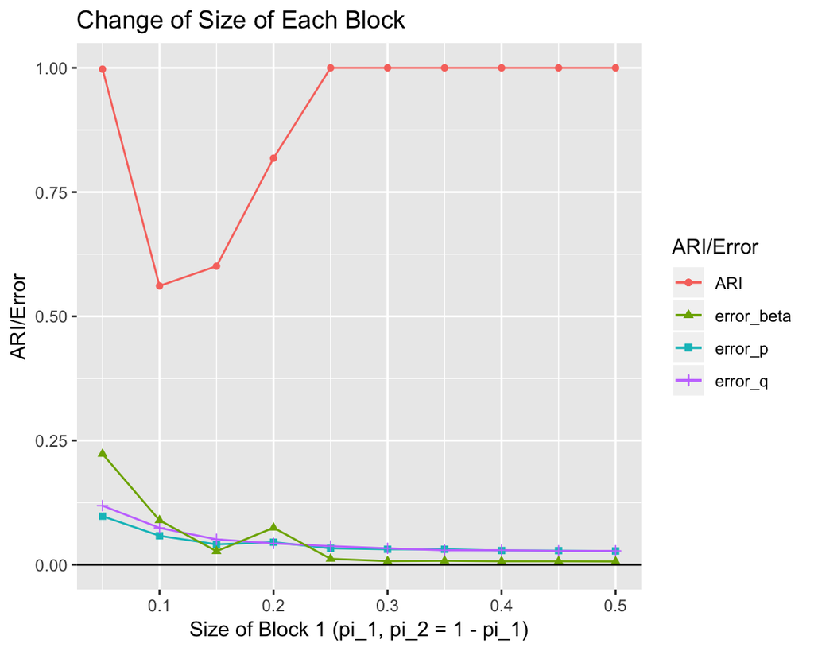

### **pi_z_1 = pi_z_2 = 0.5, p = -1.5, q = 1.5, beta = 1**

| n | pi_1 | pi_2 | p | q | phat | qhat | beta | betahat | ARI |
| --- | --- | --- | --- | --- | --- | --- | --- | --- | --- |
| 2000 | 0.05 | 0.95 | -1.5 | 1.5 | -1.703578 | 1.492791 | 1 | 1.2215463 | 0.9974763 |
| 2000 | 0.05 | 0.95 | -1.5 | 1.5 | -1.496593 | 1.696683 | 1 | 1.2111564 | 0.9974763 |
| 2000 | 0.05 | 0.95 | -1.5 | 1.5 | -1.492552 | 1.709630 | 1 | 1.2298695 | 0.9974763 |
| 2000 | 0.05 | 0.95 | -1.5 | 1.5 | -1.699104 | 1.492813 | 1 | 1.2003732 | 0.9974763 |
| 2000 | 0.05 | 0.95 | -1.5 | 1.5 | -1.491866 | 1.703084 | 1 | 1.2186010 | 0.9974763 |
| 2000 | 0.05 | 0.95 | -1.5 | 1.5 | -1.490272 | 1.708791 | 1 | 1.2265731 | 0.9974763 |
| 2000 | 0.05 | 0.95 | -1.5 | 1.5 | -1.697257 | 1.492590 | 1 | 1.2055485 | 0.9974763 |
| 2000 | 0.05 | 0.95 | -1.5 | 1.5 | -1.699497 | 1.498669 | 1 | 1.2253064 | 0.9974763 |
| 2000 | 0.05 | 0.95 | -1.5 | 1.5 | -1.492408 | 1.707326 | 1 | 1.2165900 | 0.9974763 |
| 2000 | 0.05 | 0.95 | -1.5 | 1.5 | -1.488099 | 1.734000 | 1 | 1.2343760 | 0.9974763 |
| 2000 | 0.05 | 0.95 | -1.5 | 1.5 | -1.490838 | 1.712729 | 1 | 1.2298101 | 0.9974763 |
| 2000 | 0.05 | 0.95 | -1.5 | 1.5 | -1.489428 | 1.718554 | 1 | 1.2272055 | 0.9974763 |
| 2000 | 0.05 | 0.95 | -1.5 | 1.5 | -1.492871 | 1.707213 | 1 | 1.2178177 | 0.9974763 |
| 2000 | 0.05 | 0.95 | -1.5 | 1.5 | -1.495880 | 1.698264 | 1 | 1.2179773 | 0.9974763 |
| 2000 | 0.05 | 0.95 | -1.5 | 1.5 | -1.699773 | 1.493203 | 1 | 1.2099935 | 0.9974763 |
| 2000 | 0.05 | 0.95 | -1.5 | 1.5 | -1.488484 | 1.713491 | 1 | 1.2369150 | 0.9974763 |
| 2000 | 0.05 | 0.95 | -1.5 | 1.5 | -1.692140 | 1.494197 | 1 | 1.2088953 | 0.9974763 |
| 2000 | 0.05 | 0.95 | -1.5 | 1.5 | -1.490412 | 1.723805 | 1 | 1.2401477 | 0.9974763 |
| 2000 | 0.05 | 0.95 | -1.5 | 1.5 | -1.492297 | 1.713083 | 1 | 1.2336138 | 0.9974763 |
| 2000 | 0.05 | 0.95 | -1.5 | 1.5 | -1.700556 | 1.496033 | 1 | 1.2056302 | 0.9974763 |
| 2000 | 0.05 | 0.95 | -1.5 | 1.5 | -1.711331 | 1.491562 | 1 | 1.2216885 | 0.9974763 |
| 2000 | 0.05 | 0.95 | -1.5 | 1.5 | -1.492594 | 1.706640 | 1 | 1.2253865 | 0.9974763 |
| 2000 | 0.05 | 0.95 | -1.5 | 1.5 | -1.694580 | 1.497051 | 1 | 1.2003706 | 0.9974763 |
| 2000 | 0.05 | 0.95 | -1.5 | 1.5 | -1.490431 | 1.723088 | 1 | 1.2238164 | 0.9974763 |
| 2000 | 0.05 | 0.95 | -1.5 | 1.5 | -1.719886 | 1.488425 | 1 | 1.2237913 | 0.9974763 |
| 2000 | 0.05 | 0.95 | -1.5 | 1.5 | -1.718535 | 1.486607 | 1 | 1.2334295 | 0.9974763 |
| 2000 | 0.05 | 0.95 | -1.5 | 1.5 | -1.704491 | 1.496352 | 1 | 1.2136332 | 0.9974763 |
| 2000 | 0.05 | 0.95 | -1.5 | 1.5 | -1.703863 | 1.492229 | 1 | 1.2288475 | 0.9974763 |
| 2000 | 0.05 | 0.95 | -1.5 | 1.5 | -1.490692 | 1.713554 | 1 | 1.2353296 | 0.9974763 |
| 2000 | 0.05 | 0.95 | -1.5 | 1.5 | -1.492862 | 1.712287 | 1 | 1.2335458 | 0.9974763 |

[output cut: 970 more lines]

# Change of Proportion of One Binary Covariate

### **pi_1 = pi_2 = 0.5, p = -1.5, q = 1.5, beta = 1**

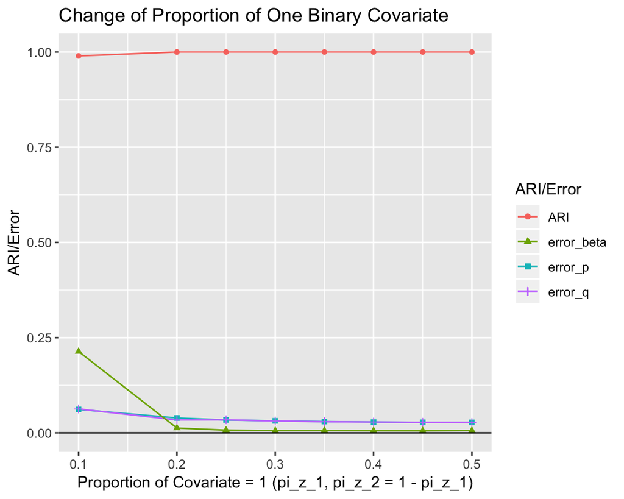

### **pi_1 = pi_2 = 0.5, p = -1.5, q = 1.5, beta = 1**

| n | pi_z_1 | pi_z_2 | p | q | phat | qhat | beta | betahat | ARI |
| --- | --- | --- | --- | --- | --- | --- | --- | --- | --- |
| 2000 | 0.10 | 0.90 | -1.5 | 1.5 | -1.567452 | 1.557344 | 1 | 0.7867885 | 0.989677 |
| 2000 | 0.10 | 0.90 | -1.5 | 1.5 | -1.559254 | 1.566679 | 1 | 0.7878385 | 0.989677 |
| 2000 | 0.10 | 0.90 | -1.5 | 1.5 | -1.561462 | 1.556649 | 1 | 0.7776620 | 0.989677 |
| 2000 | 0.10 | 0.90 | -1.5 | 1.5 | -1.566046 | 1.558437 | 1 | 0.7925213 | 0.989677 |
| 2000 | 0.10 | 0.90 | -1.5 | 1.5 | -1.559603 | 1.565315 | 1 | 0.7825170 | 0.989677 |
| 2000 | 0.10 | 0.90 | -1.5 | 1.5 | -1.559756 | 1.563651 | 1 | 0.7849416 | 0.989677 |
| 2000 | 0.10 | 0.90 | -1.5 | 1.5 | -1.562157 | 1.562384 | 1 | 0.7820462 | 0.989677 |
| 2000 | 0.10 | 0.90 | -1.5 | 1.5 | -1.558825 | 1.560750 | 1 | 0.7824769 | 0.989677 |
| 2000 | 0.10 | 0.90 | -1.5 | 1.5 | -1.568238 | 1.559000 | 1 | 0.7859708 | 0.989677 |
| 2000 | 0.10 | 0.90 | -1.5 | 1.5 | -1.563998 | 1.561576 | 1 | 0.7916996 | 0.989677 |
| 2000 | 0.10 | 0.90 | -1.5 | 1.5 | -1.556317 | 1.569848 | 1 | 0.7896869 | 0.989677 |
| 2000 | 0.10 | 0.90 | -1.5 | 1.5 | -1.561562 | 1.561439 | 1 | 0.7821970 | 0.989677 |
| 2000 | 0.10 | 0.90 | -1.5 | 1.5 | -1.564309 | 1.561422 | 1 | 0.7908599 | 0.989677 |
| 2000 | 0.10 | 0.90 | -1.5 | 1.5 | -1.564237 | 1.558654 | 1 | 0.7840598 | 0.989677 |
| 2000 | 0.10 | 0.90 | -1.5 | 1.5 | -1.566037 | 1.560828 | 1 | 0.7989876 | 0.989677 |
| 2000 | 0.10 | 0.90 | -1.5 | 1.5 | -1.556794 | 1.569679 | 1 | 0.7926438 | 0.989677 |
| 2000 | 0.10 | 0.90 | -1.5 | 1.5 | -1.563168 | 1.560428 | 1 | 0.7874551 | 0.989677 |
| 2000 | 0.10 | 0.90 | -1.5 | 1.5 | -1.554156 | 1.564153 | 1 | 0.7848447 | 0.989677 |
| 2000 | 0.10 | 0.90 | -1.5 | 1.5 | -1.561001 | 1.565607 | 1 | 0.7947546 | 0.989677 |
| 2000 | 0.10 | 0.90 | -1.5 | 1.5 | -1.560677 | 1.565330 | 1 | 0.7953688 | 0.989677 |
| 2000 | 0.10 | 0.90 | -1.5 | 1.5 | -1.565360 | 1.560134 | 1 | 0.7803181 | 0.989677 |
| 2000 | 0.10 | 0.90 | -1.5 | 1.5 | -1.566728 | 1.559936 | 1 | 0.7826363 | 0.989677 |
| 2000 | 0.10 | 0.90 | -1.5 | 1.5 | -1.559367 | 1.563224 | 1 | 0.7736719 | 0.989677 |
| 2000 | 0.10 | 0.90 | -1.5 | 1.5 | -1.559713 | 1.564547 | 1 | 0.7925886 | 0.989677 |
| 2000 | 0.10 | 0.90 | -1.5 | 1.5 | -1.566693 | 1.557844 | 1 | 0.7842075 | 0.989677 |
| 2000 | 0.10 | 0.90 | -1.5 | 1.5 | -1.567339 | 1.563188 | 1 | 0.7899140 | 0.989677 |
| 2000 | 0.10 | 0.90 | -1.5 | 1.5 | -1.562518 | 1.563178 | 1 | 0.7797771 | 0.989677 |
| 2000 | 0.10 | 0.90 | -1.5 | 1.5 | -1.560288 | 1.564135 | 1 | 0.7893385 | 0.989677 |
| 2000 | 0.10 | 0.90 | -1.5 | 1.5 | -1.561262 | 1.562210 | 1 | 0.7824758 | 0.989677 |
| 2000 | 0.10 | 0.90 | -1.5 | 1.5 | -1.555532 | 1.569221 | 1 | 0.7822208 | 0.989677 |

[output cut: 674 more lines]

# Change of Size of Each Block and Proportion of One Binary Covariate

### **p = -1.5, q = 1.5, beta = 1**

| n | pi_1 | pi_2 | pi_z_11 | pi_z_12 | pi_z_21 | pi_z_22 | p | q | phat | qhat | beta | betahat | ARI |
| --- | --- | --- | --- | --- | --- | --- | --- | --- | --- | --- | --- | --- | --- |
| 2000 | 0.1 | 0.9 | 0.1 | 0.9 | 0.1 | 0.9 | -1.5 | 1.5 | -1.5463123 | 1.5541976 | 1 | 0.9525390 | 0.4061116 |
| 2000 | 0.1 | 0.9 | 0.1 | 0.9 | 0.1 | 0.9 | -1.5 | 1.5 | -1.5413300 | 1.5495460 | 1 | 0.9461530 | 0.4472987 |
| 2000 | 0.1 | 0.9 | 0.1 | 0.9 | 0.1 | 0.9 | -1.5 | 1.5 | -1.5517657 | 1.5270853 | 1 | 0.9325038 | 0.5060973 |
| 2000 | 0.1 | 0.9 | 0.1 | 0.9 | 0.1 | 0.9 | -1.5 | 1.5 | -1.5443013 | 1.5478171 | 1 | 0.9381876 | 0.4097128 |
| 2000 | 0.1 | 0.9 | 0.1 | 0.9 | 0.1 | 0.9 | -1.5 | 1.5 | -1.5496373 | 1.5364240 | 1 | 0.9400836 | 0.4079541 |
| 2000 | 0.1 | 0.9 | 0.1 | 0.9 | 0.1 | 0.9 | -1.5 | 1.5 | -1.5372978 | 1.5667259 | 1 | 0.9761380 | 0.2736224 |
| 2000 | 0.1 | 0.9 | 0.1 | 0.9 | 0.1 | 0.9 | -1.5 | 1.5 | -1.5393268 | 1.5467908 | 1 | 0.9405788 | 0.3388785 |
| 2000 | 0.1 | 0.9 | 0.1 | 0.9 | 0.1 | 0.9 | -1.5 | 1.5 | -1.5469431 | 1.5429244 | 1 | 0.9603123 | 0.2894243 |
| 2000 | 0.1 | 0.9 | 0.1 | 0.9 | 0.1 | 0.9 | -1.5 | 1.5 | -1.5495132 | 1.5460459 | 1 | 0.9450556 | 0.4916306 |
| 2000 | 0.1 | 0.9 | 0.1 | 0.9 | 0.1 | 0.9 | -1.5 | 1.5 | -1.5502883 | 1.5405525 | 1 | 0.9640154 | 0.4194097 |
| 2000 | 0.1 | 0.9 | 0.1 | 0.9 | 0.1 | 0.9 | -1.5 | 1.5 | -1.5230921 | 1.5550001 | 1 | 0.9117089 | 0.6414001 |
| 2000 | 0.1 | 0.9 | 0.1 | 0.9 | 0.1 | 0.9 | -1.5 | 1.5 | -1.5368982 | 1.5479395 | 1 | 0.9419108 | 0.2913947 |
| 2000 | 0.1 | 0.9 | 0.1 | 0.9 | 0.1 | 0.9 | -1.5 | 1.5 | -1.3352367 | 1.6276619 | 1 | 0.6283961 | 0.2953444 |
| 2000 | 0.1 | 0.9 | 0.1 | 0.9 | 0.1 | 0.9 | -1.5 | 1.5 | -1.5555416 | 1.5413361 | 1 | 0.9691005 | 0.4529648 |
| 2000 | 0.1 | 0.9 | 0.1 | 0.9 | 0.1 | 0.9 | -1.5 | 1.5 | -1.5430773 | 1.5474033 | 1 | 0.9621676 | 0.3363821 |
| 2000 | 0.1 | 0.9 | 0.1 | 0.9 | 0.1 | 0.9 | -1.5 | 1.5 | -1.5639151 | 1.5408489 | 1 | 0.9666789 | 0.2749211 |
| 2000 | 0.1 | 0.9 | 0.1 | 0.9 | 0.1 | 0.9 | -1.5 | 1.5 | -1.5178973 | 1.5546926 | 1 | 0.9139215 | 0.4034181 |
| 2000 | 0.1 | 0.9 | 0.1 | 0.9 | 0.1 | 0.9 | -1.5 | 1.5 | -1.5566095 | 1.5435453 | 1 | 0.9712904 | 0.4565400 |
| 2000 | 0.1 | 0.9 | 0.1 | 0.9 | 0.1 | 0.9 | -1.5 | 1.5 | -1.5480670 | 1.5347038 | 1 | 0.9470297 | 0.4557340 |
| 2000 | 0.1 | 0.9 | 0.1 | 0.9 | 0.1 | 0.9 | -1.5 | 1.5 | -1.5440652 | 1.5449846 | 1 | 0.9558088 | 0.4108463 |
| 2000 | 0.1 | 0.9 | 0.1 | 0.9 | 0.1 | 0.9 | -1.5 | 1.5 | -1.5387727 | 1.5451859 | 1 | 0.9477608 | 0.4063861 |
| 2000 | 0.1 | 0.9 | 0.1 | 0.9 | 0.1 | 0.9 | -1.5 | 1.5 | -1.5449622 | 1.5428491 | 1 | 0.9508156 | 0.3472928 |
| 2000 | 0.1 | 0.9 | 0.1 | 0.9 | 0.1 | 0.9 | -1.5 | 1.5 | -1.5561604 | 1.5411561 | 1 | 0.9611803 | 0.3455116 |
| 2000 | 0.1 | 0.9 | 0.1 | 0.9 | 0.1 | 0.9 | -1.5 | 1.5 | -1.5598782 | 1.5403986 | 1 | 0.9630506 | 0.3190720 |
| 2000 | 0.1 | 0.9 | 0.1 | 0.9 | 0.1 | 0.9 | -1.5 | 1.5 | -1.5535936 | 1.5214804 | 1 | 0.9065308 | 0.4476652 |
| 2000 | 0.1 | 0.9 | 0.1 | 0.9 | 0.1 | 0.9 | -1.5 | 1.5 | -1.5494626 | 1.5346687 | 1 | 0.9400494 | 0.4284758 |
| 2000 | 0.1 | 0.9 | 0.1 | 0.9 | 0.1 | 0.9 | -1.5 | 1.5 | -1.5599973 | 1.5397446 | 1 | 0.9752728 | 0.2776881 |
| 2000 | 0.1 | 0.9 | 0.1 | 0.9 | 0.1 | 0.9 | -1.5 | 1.5 | -1.5441970 | 1.5461915 | 1 | 0.9544642 | 0.4513725 |
| 2000 | 0.1 | 0.9 | 0.1 | 0.9 | 0.1 | 0.9 | -1.5 | 1.5 | -1.5375717 | 1.5497498 | 1 | 0.9390191 | 0.5998500 |
| 2000 | 0.1 | 0.9 | 0.1 | 0.9 | 0.1 | 0.9 | -1.5 | 1.5 | -1.5442316 | 1.5505620 | 1 | 0.9601594 | 0.4149941 |

[output cut: 3081 more lines]